# bitlyAnalysis

## Part 1: Bitly Analysis

The first few blocks replicate the Bitly analysis from chapter 14 to get you started. There will be a transistion phase where you can complete duplicating the text project. And then the remainder of the project is left for you to copy over.

## Your task

Your task is to do a similar analysis and processing in Python considering **domain names from the 'u' column of data. 'u' is for URL.** Just as there were many different timezones and many observations on the same timezone, there are many domains and many observations on those domains.

You may revise the code below to directly alter the analysis for your task. OR if you wish, replicate the code below in additional chunks to accomplish the task. Please make it clear where your alterations are found.

```python
import json
path = 'Dropbox/Charley/Juniata/Data Science Masters/Data Acquisition & Visualization/example.txt'
open(path).readline()
```

```
'{ "a": "Mozilla\\/5.0 (Windows NT 6.1; WOW64) AppleWebKit\\/535.11 (KHTML, like Gecko) Chrome\\/17.0.963.78 Safari\\/535.11", "c": "US", "nk": 1, "tz": "America\\/New_York", "gr": "MA", "g": "A6qOVH", "h": "wfLQtf", "l": "orofrog", "al": "en-US,en;q=0.8", "hh": "1.usa.gov", "r": "http:\\/\\/www.fac…
```

```python
records = [json.loads(line) for line in open(path)]
records[0]
```

```
{'a': 'Mozilla/5.0 (Windows NT 6.1; WOW64) AppleWebKit/535.11 (KHTML, like Gecko) Chrome/17.0.963.78 Safari/535.11',
 'c': 'US',
 'nk': 1,
 'tz': 'America/New_York',
 'gr': 'MA',
 'g': 'A6qOVH',
 'h': 'wfLQtf',
 'l': 'orofrog',
 'al': 'en-US,en;q=0.8',
 'hh': '1.usa.gov',
 'r': 'http://www.facebook.com/l/7AQEFzjSi/1.usa.gov/wfLQtf',
 'u': 'http://www.ncbi.nlm.nih.gov/pubmed/22415991',
 't': 1331923247,
 'hc': 1331822918,
 'cy': 'Danvers',
 'll': [42.576698, -70.954903]}
```

```python
import pandas as pd
frame = pd.DataFrame(records)
frame.info()
```

```
<class 'pandas.core.frame.DataFrame'>
RangeIndex: 3560 entries, 0 to 3559
Data columns (total 18 columns):
 #   Column       Non-Null Count  Dtype
---  ------       --------------  -----
 0   a            3440 non-null   object
 1   c            2919 non-null   object
 2   nk           3440 non-null   float64
 3   tz           3440 non-null   object
 4   gr           2919 non-null   object
 5   g            3440 non-null   object
 6   h            3440 non-null   object
 7   l            3440 non-null   object
 8   al           3094 non-null   object
 9   hh           3440 non-null   object
 10  r            3440 non-null   object
 11  u            3440 non-null   object
 12  t            3440 non-null   float64
 13  hc           3440 non-null   float64
 14  cy           2919 non-null   object
 15  ll           2919 non-null   object
 16  _heartbeat_  120 non-null    float64
 17  kw           93 non-null     object
dtypes: float64(4), object(14)
memory usage: 500.8+ KB
```

```python
frame['tz'][:10]
```

```
0     America/New_York
1       America/Denver
2     America/New_York
3    America/Sao_Paulo
4     America/New_York
5     America/New_York
6        Europe/Warsaw
7
8
9
Name: tz, dtype: object
```

```python
frame['u'][:10] # duplicated the chunk above but looked at the u column instead.
```

```
0          http://www.ncbi.nlm.nih.gov/pubmed/22415991
1          http://www.monroecounty.gov/etc/911/rss.php
2    http://boxer.senate.gov/en/press/releases/0316...
3              http://apod.nasa.gov/apod/ap120312.html
4    http://www.shrewsbury-ma.gov/egov/gallery/1341...
5    http://www.shrewsbury-ma.gov/egov/gallery/1341...
6    http://www.nasa.gov/mission_pages/nustar/main/...
7    http://www.nasa.gov/mission_pages/nustar/main/...
8    http://www.nasa.gov/mission_pages/nustar/main/...
9              http://apod.nasa.gov/apod/ap120312.html
Name: u, dtype: object
```

```python
clean_tz = frame['tz'].fillna('Missing')
clean_tz[clean_tz == ''] = 'Unknown'
tz_counts = clean_tz.value_counts()
tz_counts[:10]
```

```
tz
America/New_York       1251
Unknown                 521
America/Chicago         400
America/Los_Angeles     382
America/Denver          191
Missing                 120
Europe/London            74
Asia/Tokyo               37
Pacific/Honolulu         36
Europe/Madrid            35
Name: count, dtype: int64
```

```python
clean_u = frame['u'].fillna('Missing') # duplicated the chunk above but looked at the u column instead.
clean_u[clean_u == ''] = 'Unknown'
u_counts = clean_u.value_counts()
print(u_counts[:10])
clean_u[clean_u=="Unknown"] # checked to see if there were actually "Unknown" values in the dataframe and there weren't any.
```

```
u
https://www.nysdot.gov/rexdesign/design/community.gif                  836
http://www.nasa.gov/mission_pages/nustar/main/index.html               425
http://www.nasa.gov/multimedia/imagegallery/image_feature_2199.html    129
http://www.monroecounty.gov/etc/911/rss.php                            121
Missing                                                                120
http://www.bls.gov/cps/cpsdisability.htm/                               60
http://www.fda.gov/Safety/Recalls/ucm296326.htm                         50
http://www.shrewsbury-ma.gov/egov/gallery/134127368672998.png           47
http://www.shrewsbury-ma.gov/egov/gallery/134127368675393.png           47
http://www.whitehouse.gov/energy/gasprices#.T2NboBE2Aok.twitter         37
Name: count, dtype: int64
```

```
Series([], Name: u, dtype: object)
```

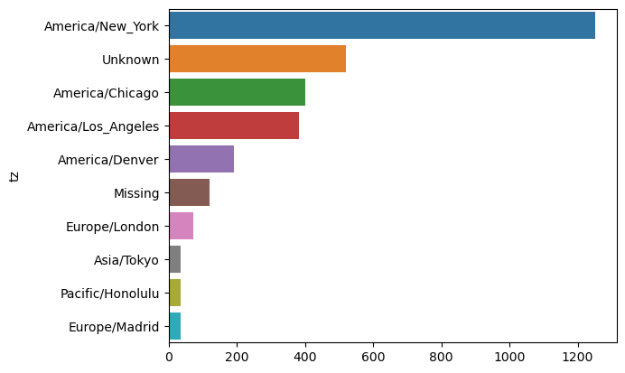

```python
import seaborn as sns
subset = tz_counts[:10]
sns.barplot(y=subset.index, x=subset.values)
```

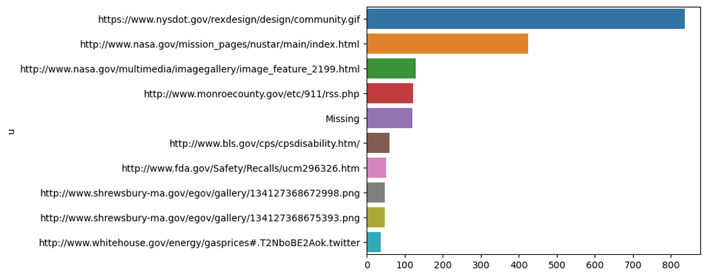

```python
u_subset = u_counts[:10] # looked at count by u column.
sns.barplot(y=u_subset.index, x=u_subset.values)
```

```python
# a few commands to peek at the data
print(frame['a'][1])
print(frame['a'][50])
print(frame['a'][51][:50])  # long line
results = pd.Series([x.split()[0] for x in frame.a.dropna()])
results[:5]
```

```
GoogleMaps/RochesterNY
Mozilla/5.0 (Windows NT 5.1; rv:10.0.2) Gecko/20100101 Firefox/10.0.2
Mozilla/5.0 (Linux; U; Android 2.2.2; en-us; LG-P9
```

```
0               Mozilla/5.0
1    GoogleMaps/RochesterNY
2               Mozilla/4.0
3               Mozilla/5.0
4               Mozilla/5.0
dtype: object
```

```python
import numpy as np
cframe = frame[frame.a.notnull()]
# the next command generates a warning that you can ignore
cframe['os'] = np.where(cframe['a'].str.contains('Windows'),
                        'Windows', 'Not Windows')
cframe['os'][:5]
```

```
0        Windows
1    Not Windows
2        Windows
3    Not Windows
4        Windows
Name: os, dtype: object
```

Continue copying over the steps from the text and trying them out.

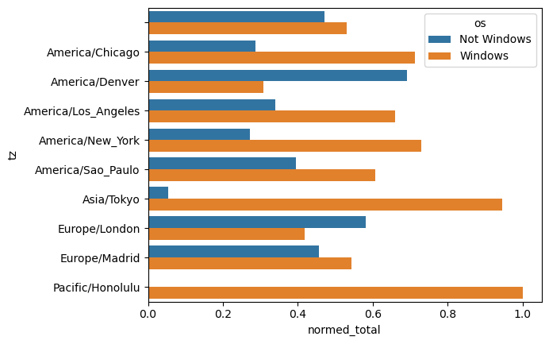

```python
by_tz_os = cframe.groupby(['tz', 'os'])
agg_counts = by_tz_os.size().unstack().fillna(0)
indexer = agg_counts.sum(1).argsort()
count_subset = agg_counts.take(indexer[-10:])
count_subset = count_subset.stack()
count_subset.name = 'total'
count_subset = count_subset.reset_index()
def norm_total(group):
    group['normed_total'] = group.total / group.total.sum()
    return group
results = count_subset.groupby('tz').apply(norm_total)
sns.barplot(x='normed_total', y='tz', hue='os',  data=results)
```

```python
cframe = frame[frame.u.notnull()] # copied from two chunks earlier, but I look for html instead of Windows.

cframe['p'] = np.where(cframe['u'].str.contains('html'),
                        'Contains html', 'Does Not Contain html')
cframe['p'][:5]
```

```
0    Does Not Contain html
1    Does Not Contain html
2    Does Not Contain html
3            Contains html
4    Does Not Contain html
Name: p, dtype: object
```

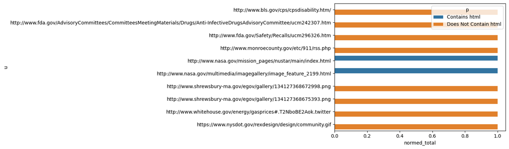

```python
by_url_os = cframe.groupby(['u', 'p']) # basically just made the same graph but with u instead of tz, and checking for html instead of Windows.
agg_counts = by_url_os.size().unstack().fillna(0)
indexer = agg_counts.sum(1).argsort()
count_subset = agg_counts.take(indexer[-10:])
count_subset = count_subset.stack()
count_subset.name = 'total'
count_subset = count_subset.reset_index()
def norm_total(group):
    group['normed_total'] = group.total / group.total.sum()
    return group
results = count_subset.groupby('u').apply(norm_total)
sns.barplot(x='normed_total', y='u', hue='p',  data=results)
```

## Part 2: COVID-19 Analysis

Read the confirmed US or US deaths data set into a dataframe. Do the task as outlined in the assignment page.

```python
# Name: Charley Kirk
# Date: 09/26/24
# Synopsis: This program reads data on coronavirus cases and coronavirus deaths and looks at cases and deaths over a period of time.

# set up for the pandas library
import csv
import pandas as pd
from pandas import Series, DataFrame

# input the file contents into dataFrames.
cUS = pd.read_csv("/Users/Charley/Dropbox/Charley/Juniata/Data Science Masters/Data Acquisition & Visualization/time_series_covid19_confirmed_US.csv")
dUS = pd.read_csv("/Users/Charley/Dropbox/Charley/Juniata/Data Science Masters/Data Acquisition & Visualization/time_series_covid19_deaths_US.csv")
print(cUS)
dUS
```

```
           UID iso2 iso3  code3     FIPS      Admin2 Province_State  \
0     84001001   US  USA    840   1001.0     Autauga        Alabama
1     84001003   US  USA    840   1003.0     Baldwin        Alabama
2     84001005   US  USA    840   1005.0     Barbour        Alabama
3     84001007   US  USA    840   1007.0        Bibb        Alabama
4     84001009   US  USA    840   1009.0      Blount        Alabama
...        ...  ...  ...    ...      ...         ...            ...
3337  84056039   US  USA    840  56039.0       Teton        Wyoming
3338  84056041   US  USA    840  56041.0       Uinta        Wyoming
3339  84090056   US  USA    840  90056.0  Unassigned        Wyoming
3340  84056043   US  USA    840  56043.0    Washakie        Wyoming
3341  84056045   US  USA    840  56045.0      Weston        Wyoming

     Country_Region        Lat       Long_  ... 2/28/23  3/1/23  3/2/23  \
0                US  32.539527  -86.644082  ...   19732   19759   19759
```

[output cut: 25 more lines]

|  | UID | iso2 | iso3 | code3 | FIPS | Admin2 | Province_State | Country_Region | Lat | Long_ | ... | 2/28/23 | 3/1/23 | 3/2/23 | 3/3/23 | 3/4/23 | 3/5/23 | 3/6/23 | 3/7/23 | 3/8/23 | 3/9/23 |
| --- | --- | --- | --- | --- | --- | --- | --- | --- | --- | --- | --- | --- | --- | --- | --- | --- | --- | --- | --- | --- | --- |
| 0 | 84001001 | US | USA | 840 | 1001.0 | Autauga | Alabama | US | 32.539527 | -86.644082 | ... | 230 | 232 | 232 | 232 | 232 | 232 | 232 | 232 | 232 | 232 |
| 1 | 84001003 | US | USA | 840 | 1003.0 | Baldwin | Alabama | US | 30.727750 | -87.722071 | ... | 724 | 726 | 726 | 726 | 726 | 726 | 726 | 726 | 727 | 727 |
| 2 | 84001005 | US | USA | 840 | 1005.0 | Barbour | Alabama | US | 31.868263 | -85.387129 | ... | 103 | 103 | 103 | 103 | 103 | 103 | 103 | 103 | 103 | 103 |
| 3 | 84001007 | US | USA | 840 | 1007.0 | Bibb | Alabama | US | 32.996421 | -87.125115 | ... | 109 | 109 | 109 | 109 | 109 | 109 | 109 | 109 | 109 | 109 |
| 4 | 84001009 | US | USA | 840 | 1009.0 | Blount | Alabama | US | 33.982109 | -86.567906 | ... | 261 | 261 | 261 | 261 | 261 | 261 | 261 | 261 | 261 | 261 |
| ... | ... | ... | ... | ... | ... | ... | ... | ... | ... | ... | ... | ... | ... | ... | ... | ... | ... | ... | ... | ... | ... |
| 3337 | 84056039 | US | USA | 840 | 56039.0 | Teton | Wyoming | US | 43.935225 | -110.589080 | ... | 16 | 16 | 16 | 16 | 16 | 16 | 16 | 16 | 16 | 16 |
| 3338 | 84056041 | US | USA | 840 | 56041.0 | Uinta | Wyoming | US | 41.287818 | -110.547578 | ... | 43 | 43 | 43 | 43 | 43 | 43 | 43 | 43 | 43 | 43 |
| 3339 | 84090056 | US | USA | 840 | 90056.0 | Unassigned | Wyoming | US | 0.000000 | 0.000000 | ... | 0 | 0 | 0 | 0 | 0 | 0 | 0 | 0 | 0 | 0 |
| 3340 | 84056043 | US | USA | 840 | 56043.0 | Washakie | Wyoming | US | 43.904516 | -107.680187 | ... | 50 | 50 | 50 | 50 | 50 | 50 | 50 | 51 | 51 | 51 |
| 3341 | 84056045 | US | USA | 840 | 56045.0 | Weston | Wyoming | US | 43.839612 | -104.567488 | ... | 23 | 23 | 23 | 23 | 23 | 23 | 23 | 23 | 23 | 23 |

3342 rows × 1155 columns

```python
cUS.info()
```

```
<class 'pandas.core.frame.DataFrame'>
RangeIndex: 3342 entries, 0 to 3341
Columns: 1154 entries, UID to 3/9/23
dtypes: float64(3), int64(1145), object(6)
memory usage: 29.4+ MB
```

```python
cUS[cUS.isnull().any(axis=1)]
```

|  | UID | iso2 | iso3 | code3 | FIPS | Admin2 | Province_State | Country_Region | Lat | Long_ | ... | 2/28/23 | 3/1/23 | 3/2/23 | 3/3/23 | 3/4/23 | 3/5/23 | 3/6/23 | 3/7/23 | 3/8/23 | 3/9/23 |
| --- | --- | --- | --- | --- | --- | --- | --- | --- | --- | --- | --- | --- | --- | --- | --- | --- | --- | --- | --- | --- | --- |
| 102 | 16 | AS | ASM | 16 | 60.0 | NaN | American Samoa | US | -14.271000 | -170.132000 | ... | 8320 | 8320 | 8320 | 8320 | 8320 | 8320 | 8320 | 8320 | 8320 | 8320 |
| 338 | 84088888 | US | USA | 840 | 88888.0 | NaN | Diamond Princess | US | 0.000000 | 0.000000 | ... | 49 | 49 | 49 | 49 | 49 | 49 | 49 | 49 | 49 | 49 |
| 572 | 84099999 | US | USA | 840 | 99999.0 | NaN | Grand Princess | US | 0.000000 | 0.000000 | ... | 103 | 103 | 103 | 103 | 103 | 103 | 103 | 103 | 103 | 103 |
| 573 | 316 | GU | GUM | 316 | 66.0 | NaN | Guam | US | 13.444300 | 144.793700 | ... | 60989 | 60997 | 61001 | 61002 | 61002 | 61002 | 61002 | 61018 | 61019 | 61027 |
| 1269 | 84070002 | US | USA | 840 | NaN | Dukes and Nantucket | Massachusetts | US | 41.406747 | -70.687635 | ... | 8299 | 8299 | 8306 | 8306 | 8306 | 8306 | 8306 | 8306 | 8306 | 8316 |
| 1306 | 84070005 | US | USA | 840 | NaN | Federal Correctional Institution (FCI) | Michigan | US | 0.000000 | 0.000000 | ... | 329 | 329 | 329 | 329 | 329 | 329 | 329 | 329 | 329 | 329 |
| 1338 | 84070004 | US | USA | 840 | NaN | Michigan Department of Corrections (MDOC) | Michigan | US | 0.000000 | 0.000000 | ... | 42491 | 42491 | 42491 | 42491 | 42491 | 42491 | 42491 | 42516 | 42516 | 42516 |
| 1593 | 84070003 | US | USA | 840 | NaN | Kansas City | Missouri | US | 39.099700 | -94.578600 | ... | 139510 | 139510 | 139510 | 139510 | 139510 | 139510 | 139510 | 139772 | 139772 | 139772 |
| 2123 | 580 | MP | MNP | 580 | 69.0 | NaN | Northern Mariana Islands | US | 15.097900 | 145.673900 | ... | 13631 | 13631 | 13631 | 13666 | 13666 | 13666 | 13666 | 13666 | 13666 | 13666 |
| 2956 | 84070015 | US | USA | 840 | NaN | Bear River | Utah | US | 41.521068 | -113.083282 | ... | 58041 | 58041 | 58131 | 58131 | 58131 | 58131 | 58131 | 58131 | 58131 | 58205 |
| 2961 | 84070016 | US | USA | 840 | NaN | Central Utah | Utah | US | 39.372319 | -111.575868 | ... | 22902 | 22902 | 22937 | 22937 | 22937 | 22937 | 22937 | 22937 | 22937 | 22956 |
| 2980 | 84070017 | US | USA | 840 | NaN | Southeast Utah | Utah | US | 38.996171 | -110.701396 | ... | 11912 | 11912 | 11932 | 11932 | 11932 | 11932 | 11932 | 11932 | 11932 | 11943 |
| 2981 | 84070018 | US | USA | 840 | NaN | Southwest Utah | Utah | US | 37.854472 | -111.441876 | ... | 72408 | 72408 | 72491 | 72491 | 72491 | 72491 | 72491 | 72491 | 72491 | 72559 |
| 2984 | 84070019 | US | USA | 840 | NaN | TriCounty | Utah | US | 40.124915 | -109.517442 | ... | 14910 | 14910 | 14944 | 14944 | 14944 | 14944 | 14944 | 14944 | 14944 | 14966 |
| 2992 | 84070020 | US | USA | 840 | NaN | Weber-Morgan | Utah | US | 41.271160 | -111.914512 | ... | 89234 | 89234 | 89421 | 89421 | 89421 | 89421 | 89421 | 89421 | 89421 | 89619 |
| 3009 | 850 | VI | VIR | 850 | 78.0 | NaN | Virgin Islands | US | 18.335800 | -64.896300 | ... | 24766 | 24774 | 24779 | 24780 | 24780 | 24780 | 24792 | 24795 | 24798 | 24813 |

16 rows × 1154 columns

```python
cUS[cUS.Country_Region!="US"]
```

|  | UID | iso2 | iso3 | code3 | FIPS | Admin2 | Province_State | Country_Region | Lat | Long_ | ... | 2/28/23 | 3/1/23 | 3/2/23 | 3/3/23 | 3/4/23 | 3/5/23 | 3/6/23 | 3/7/23 | 3/8/23 | 3/9/23 |
| --- | --- | --- | --- | --- | --- | --- | --- | --- | --- | --- | --- | --- | --- | --- | --- | --- | --- | --- | --- | --- | --- |

0 rows × 1154 columns

```python
# creates a pcUS dataframe that looks at covid cases over time across the categories of Province_State.
# I filtered out California and Diamond Princess to make the scaling of the graphs a bit better.
pcUS=cUS.groupby(["Province_State"], as_index=False)[["1/1/23", "1/2/23", "1/3/23", "1/4/23", "1/5/23", "1/6/23", "1/7/23", "1/8/23", "1/9/23", "1/10/23", "1/11/23", "1/12/23", "1/13/23", "1/14/23", "1/15/23", "1/16/23", "1/17/23", "1/18/23", "1/19/23", "1/20/23", "1/21/23", "1/22/23", "1/23/23", "1/24/23", "1/25/23", "1/26/23", "1/27/23", "1/28/23", "1/29/23", "1/30/23", "1/31/23", "2/1/23", "2/2/23", "2/3/23", "2/4/23", "2/5/23", "2/6/23", "2/7/23", "2/8/23", "2/9/23", "2/10/23", "2/11/23", "2/12/23", "2/13/23", "2/14/23", "2/15/23", "2/16/23", "2/17/23", "2/18/23", "2/19/23", "2/20/23", "2/21/23", "2/22/23", "2/23/23", "2/24/23", "2/25/23", "2/26/23", "2/27/23", "2/28/23", "3/1/23", "3/2/23", "3/3/23", "3/4/23", "3/5/23", "3/6/23",	"3/7/23", "3/8/23", "3/9/23"]].sum()
pcUS=pcUS[0:10]
pcUS = pcUS[pcUS.Province_State!="California"]
pcUS = pcUS[pcUS.Province_State!="Diamond Princess"]
print(pcUS)
pcUS = pd.melt(pcUS, "Province_State")
pcUS = pcUS.rename(columns={'variable': 'Date', 'value':'Value'})
print(pcUS)

# creates a pdUS dataframe that looks at covid deaths over time across the categories of Province_State.
pdUS=dUS.groupby(["Province_State"], as_index=False)[["1/1/23", "1/2/23", "1/3/23", "1/4/23", "1/5/23", "1/6/23", "1/7/23", "1/8/23", "1/9/23", "1/10/23", "1/11/23", "1/12/23", "1/13/23", "1/14/23", "1/15/23", "1/16/23", "1/17/23", "1/18/23", "1/19/23", "1/20/23", "1/21/23", "1/22/23", "1/23/23", "1/24/23", "1/25/23", "1/26/23", "1/27/23", "1/28/23", "1/29/23", "1/30/23", "1/31/23", "2/1/23", "2/2/23", "2/3/23", "2/4/23", "2/5/23", "2/6/23", "2/7/23", "2/8/23", "2/9/23", "2/10/23", "2/11/23", "2/12/23", "2/13/23", "2/14/23", "2/15/23", "2/16/23", "2/17/23", "2/18/23", "2/19/23", "2/20/23", "2/21/23", "2/22/23", "2/23/23", "2/24/23", "2/25/23", "2/26/23", "2/27/23", "2/28/23", "3/1/23", "3/2/23", "3/3/23", "3/4/23", "3/5/23", "3/6/23",	"3/7/23", "3/8/23", "3/9/23"]].sum()
pdUS=pdUS[0:10]
pdUS = pdUS[pdUS.Province_State!="California"]
pdUS = pdUS[pdUS.Province_State!="Diamond Princess"]
print(pdUS)
pdUS = pd.melt(pdUS, "Province_State")
pdUS = pdUS.rename(columns={'variable': 'Date', 'value':'Value'})
print(pdUS)
```

```
   Province_State   1/1/23   1/2/23   1/3/23   1/4/23   1/5/23   1/6/23  \
0         Alabama  1568934  1568934  1568934  1587224  1587224  1587224
1          Alaska   301432   301432   301803   301803   301803   301803
2  American Samoa     8266     8266     8266     8266     8285     8302
3         Arizona  2378334  2378334  2378334  2384521  2384521  2384521
4        Arkansas   985747   985945   986287   987049   987848   988489
6        Colorado  1734782  1736226  1736494  1737244  1737979  1738658
7     Connecticut   949324   949661   950046   952152   953006   953522
8        Delaware   321888   321888   321888   323151   323151   323151

    1/7/23   1/8/23   1/9/23  ...  2/28/23   3/1/23   3/2/23   3/3/23  \
0  1587224  1587224  1587224  ...  1638348  1642062  1642062  1642062
1   301803   301803   301803  ...   307073   307073   307073   307073
2     8302     8302     8302  ...     8320     8320     8320     8320
3  2384521  2384521  2384521  ...  2434631  2440294  2440294  2440294
```

[output cut: 75 more lines]

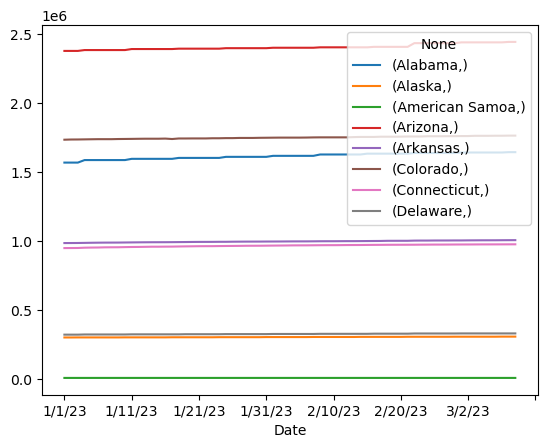

```python
# My time series for covid cases by Province_State, from 1/1/23 to 3/9/23.
from matplotlib import pyplot as plt
fig, ax = plt.subplots()


for key, data in pcUS.groupby(["Province_State"]):
    data.plot(x='Date', y='Value', ax=ax, label=key)
```

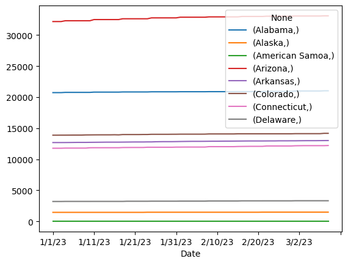

```python
# My time series for covid deaths by Province_State, from 1/1/23 to 3/9/23.
fig, ax = plt.subplots()

for key, data in pdUS.groupby(["Province_State"]):
    data.plot(x='Date', y='Value', ax=ax, label=key)
```

```
   Province_State  Covid_Cases  Covid_Deaths
0         Alabama    109891172       1419701
1          Alaska     20702616         99971
2  American Samoa       565289          2312
3         Arizona    163622026       2228796
4        Arkansas     67819013        874730
5        Colorado    119011365        954297
6     Connecticut     65732831        815411
7        Delaware     22226283        222226
    Province_State      variable      value
0          Alabama   Covid_Cases  109891172
1           Alaska   Covid_Cases   20702616
2   American Samoa   Covid_Cases     565289
3          Arizona   Covid_Cases  163622026
4         Arkansas   Covid_Cases   67819013
5         Colorado   Covid_Cases  119011365
6      Connecticut   Covid_Cases   65732831
7         Delaware   Covid_Cases   22226283
8          Alabama  Covid_Deaths    1419701
9           Alaska  Covid_Deaths      99971
10  American Samoa  Covid_Deaths       2312
11         Arizona  Covid_Deaths    2228796
12        Arkansas  Covid_Deaths     874730
13        Colorado  Covid_Deaths     954297
14     Connecticut  Covid_Deaths     815411
15        Delaware  Covid_Deaths     222226
```

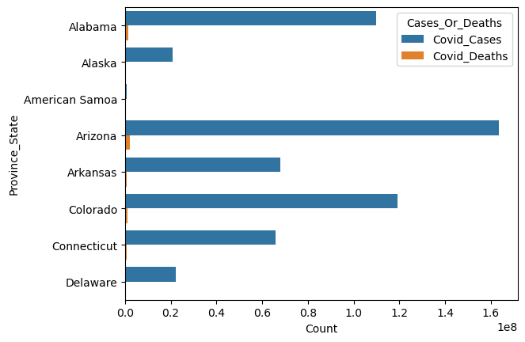

```python
# For my "simple" graph I made a side-by-side bar chart showing covid cases and covid deaths from 1/1/23 to 3/9/23 by Province_State.
kcUS=pcUS.groupby("Province_State", as_index=False)["Value"].sum()
kdUS=pdUS.groupby("Province_State", as_index=False)["Value"].sum()
kcUS = kcUS.rename(columns={'Value':'Covid_Cases'})
kdUS = kdUS.rename(columns={'Value':'Covid_Deaths'})
mUS=pd.merge(kcUS, kdUS, on='Province_State')
print(mUS)
mUS=pd.melt(mUS, 'Province_State')
print(mUS)
mUS = mUS.rename(columns={'variable':'Cases_Or_Deaths', 'value':'Count'})
sns.barplot(x='Count', y='Province_State', hue='Cases_Or_Deaths',  data=mUS)
```

I didn't end up performing any data cleaning apart from renaming some columns and performing merges and melts as needed for my graphs.